# sequential+diverging colour scheme - Google Search

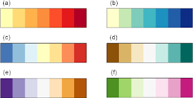

706 × 358

diverging and sequential colour schemes ...

researchgate.net

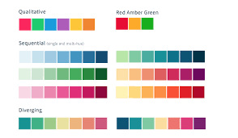

901 × 526

Another Post About Colours for Data ...

blog.prototypr.io

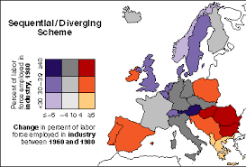

377 × 255

Color Use Guidelines

web.natur.cuni.cz

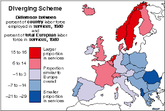

374 × 252

Color Use Guidelines

web.natur.cuni.cz

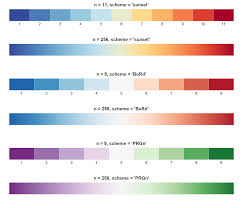

2100 × 1800

Tol Color Schemes | R-bloggers

r-bloggers.com

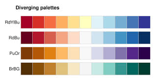

500 × 250

Diverging palettes (Color Brewer via ...

pinterest.com

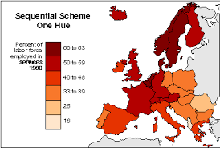

374 × 252

Color Use Guidelines

web.natur.cuni.cz

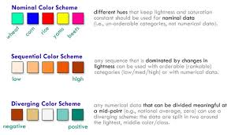

598 × 351

Using Colors on Maps

axismaps.com

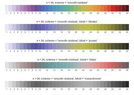

2100 × 1500

Tol Color Schemes | R-bloggers

r-bloggers.com

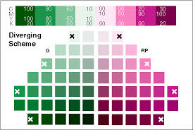

561 × 377

Diverging Color Schemes

personal.psu.edu

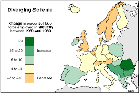

375 × 252

Color Use Guidelines

web.natur.cuni.cz

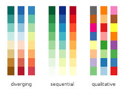

350 × 262

Color maps from colorbrewer « Gnuplotting

gnuplotting.org

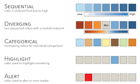

1524 × 916

Data Visualisation. Colour. - Oksana ...

medium.com

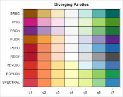

466 × 366

colors for maps and heat maps ...

blogs.sas.com

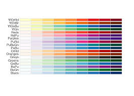

1344 × 960

Selecting optimal color palettes ...

cfss.uchicago.edu

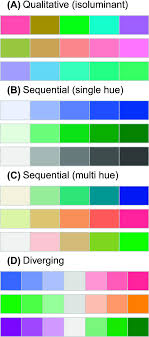

663 × 1495

Examples of different HCL color maps ...

researchgate.net

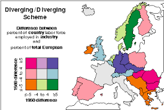

374 × 252

Color Use Guidelines

web.natur.cuni.cz

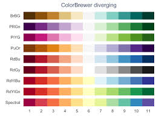

528 × 384

palettes - Color palettes, symbol ...

repec.sowi.unibe.ch

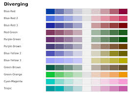

1344 × 960

Default Palettes — python-colorspace 0 ...

python-colorspace.readthedocs.io

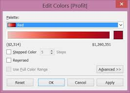

444 × 317

Sequential and Diverging Color Palettes ...

interworks.com

[figure not shown]

570 × 268

Diverging Color Palettes

docs.datawatch.com

[figure not shown]

350 × 152

Data Visualization, Design and ...

mkweb.bcgsc.ca

[figure not shown]

1498 × 1540

palette for divergent colors in R ...

stackoverflow.com

[figure not shown]

960 × 720

Lecture 6: using color and shading ...

slideplayer.com

qualitative color scheme

sequential color scheme

colour scheme generator

[figure not shown]

750 × 381

Peter Aldhous | NICAR 2016

paldhous.github.io

[figure not shown]

500 × 250

Picking a colour scale for scientific ...

betterfigures.org

[figure not shown]

850 × 597

colour schemes ...

researchgate.net

[figure not shown]

533 × 217

A better way of choosing colors ...

blog.revolutionanalytics.com

[figure not shown]

596 × 497

Diverging Color Palettes

docs.datawatch.com

[figure not shown]

1400 × 866

diverging and qualitative colour scales ...

ggplot2.tidyverse.org

[figure not shown]

828 × 425

Multi-hued Color Scales with Chroma.js

vis4.net

[figure not shown]

648 × 412

Choosing Color Schemes - Maps and the ...

futurelearn.com

[figure not shown]

669 × 402

Pick the Perfect Color Combination ...

blog.hubspot.com

[figure not shown]

14204 × 4319

Create Colorful Graphs in R with ...

moderndata.plot.ly

[figure not shown]

768 × 192

Intro to GIS and Spatial Analysis

mgimond.github.io

[figure not shown]

727 × 671

Sequential and Diverging Color Palettes ...

interworks.com

[figure not shown]

476 × 298

Color Use Guidelines

web.natur.cuni.cz

[figure not shown]

707 × 570

color palette tool for choropleth maps ...

academy.datawrapper.de

[figure not shown]

866 × 464

Color Schemes for Analytics Dashboards ...

logianalytics.com

[figure not shown]

850 × 504

Recommended colour schemes for ...

researchgate.net

[figure not shown]

816 × 864

HCL-Based Color Palettes • colorspace

colorspace.r-forge.r-project.org

[figure not shown]

1400 × 866

diverging and qualitative colour scales ...

ggplot2.tidyverse.org

[figure not shown]

780 × 480

Choosing Color Palettes in Displayr ...

displayr.com

[figure not shown]

850 × 500

colorblind-friendly graphics ...

knightlab.northwestern.edu

[figure not shown]

1500 × 569

when creating choropleth maps ...

academy.datawrapper.de

[figure not shown]

618 × 196

Elegant Figures - Subtleties of Color ...

earthobservatory.nasa.gov

[figure not shown]

528 × 384

palettes - Color palettes, symbol ...

repec.sowi.unibe.ch

blue colour schemes

pastel colour schemes

purple colour schemes

[figure not shown]

1024 × 408

Data Visualization ...

guides.lib.berkeley.edu

[figure not shown]

850 × 585

colorblind-friendly graphics ...

knightlab.northwestern.edu

[figure not shown]

669 × 402

Pick the Perfect Color Combination ...

blog.hubspot.com

[figure not shown]

1086 × 580

Color Palettes

medium.com

[figure not shown]

374 × 252

Color Use Guidelines

web.natur.cuni.cz

[figure not shown]

432 × 432

Achim Zeileis on Twitter: "New release ...

twitter.com

[figure not shown]

2100 × 600

Tol Color Schemes | R-bloggers

r-bloggers.com

[figure not shown]

1004 × 631

Use ColorBrewer for coloring maps ...

johnpremjeetpage.blogspot.com

[figure not shown]

692 × 692

don'ts for a heatmap color scale ...

blog.bioturing.com

[figure not shown]

618 × 454

Elegant Figures - Subtleties of Color ...

earthobservatory.nasa.gov

[figure not shown]

930 × 624

Dr Robbi Bishop-Taylor on Twitter ...

twitter.com

[figure not shown]

654 × 508

Generate Brewer color palette(s ...

euclid.psych.yorku.ca

[figure not shown]

1900 × 2203

colours for data visualisation ...

blog.prototypr.io

[figure not shown]

1690 × 920

12 Custom Color Palettes for macOS ...

mapdiva.com

[figure not shown]

1310 × 1128

colour palettes in data visualisation ...

home.vizlib.com

[figure not shown]

1424 × 1704

Quantitative Color Schemes ...

tandfonline.com

[figure not shown]

786 × 585

When to Use Sequential and Diverging ...

everydayanalytics.ca

[figure not shown]

799 × 552

colors for maps and heat maps ...

blogs.sas.com

[figure not shown]

955 × 508

Nominal, Sequential, or Diverging ...

depictdatastudio.com

[figure not shown]

914 × 473

inverted diverging colour palette ...

stackoverflow.com

[figure not shown]

1472 × 908

Bivariate choropleth map color scheme ...

public.tableau.com

[figure not shown]

700 × 603

How to expand color palette with ggplot ...

novyden.blogspot.com

[figure not shown]

660 × 500

Figure 23 from Big Data Visualization ...

semanticscholar.org

map color palette

interior colour schemes

green colour schemes

[figure not shown]

1152 × 153

HCL-Based Color Palettes • colorspace

colorspace.r-forge.r-project.org

[figure not shown]

998 × 619

ColorBrewer: Attractive and Distinctive ...

mathworks.com

[figure not shown]

1500 × 569

when creating choropleth maps ...

academy.datawrapper.de

[figure not shown]

2100 × 2100

Tol Color Schemes | R-bloggers

r-bloggers.com

[figure not shown]

517 × 329

Intro to GIS and Spatial Analysis

mgimond.github.io

[figure not shown]

1886 × 970

colour palettes in data visualisation ...

home.vizlib.com

[figure not shown]

648 × 412

Choosing Color Schemes - Maps and the ...

futurelearn.com

[figure not shown]

640 × 640

colour schemes ...

researchgate.net

[figure not shown]

1024 × 1016

Solved: Question4 2 Pts The Follow Is ...

chegg.com

[figure not shown]

424 × 382

When to Use Sequential and Diverging ...

everydayanalytics.ca

[figure not shown]

1712 × 419

How to Make Custom Colour Palettes ...

feedmedata.co.uk

[figure not shown]

600 × 430

Setting up Color Palettes in R ...

data.library.virginia.edu

[figure not shown]

1041 × 633

Achim Zeileis on Twitter: "#ggplot2 ...

twitter.com

[figure not shown]

810 × 450

Choosing Colors for Data Visualization ...

dataquest.io

[figure not shown]

1024 × 430

color palettes with Matplotlib ...

python-graph-gallery.com

[figure not shown]

475 × 380

Why Color is Key in Data Visualization ...

theblog.adobe.com

[figure not shown]

758 × 596

Two Sequential Color Palettes on the ...

drawingwithnumbers.artisart.org

[figure not shown]

1114 × 1114

Types of color schemes | GEOG 486 ...

e-education.psu.edu

[figure not shown]

1662 × 1101

Qualitative Color Palette - photocopy ...

gis.stackexchange.com

[figure not shown]

1170 × 548

color palette tool for choropleth maps ...

academy.datawrapper.de

[figure not shown]

1686 × 999

Creating color palettes in R – Let's ...

rjbioinformatics.com

[figure not shown]

384 × 912

HCL-Based Color Palettes • colorspace

colorspace.r-forge.r-project.org

[figure not shown]

638 × 479

Using Color to Convey Data in Charts

slideshare.net

brown colour schemes

colour schemes pink

colour schemes aesthetic

[figure not shown]

684 × 856

color palettes in Tableau 10 ...

tableau.com

[figure not shown]

728 × 546

Better Map Color Schemes With ColorBrewer

freegeographytools.com

[figure not shown]

2000 × 1333

Color Combination for Your Data ...

papdan.com

[figure not shown]

1100 × 850

Data Graphics Research

geog.uoregon.edu

[figure not shown]

712 × 458

Choosing Color Palettes in Displayr ...

displayr.com

[figure not shown]

768 × 1152

Top R Color Palettes to Know for Great ...

datanovia.com

[figure not shown]

725 × 500

Color in Charts

blog.zingchart.com

[figure not shown]

Gnuplotting

[Color maps from colorbrewer « Gnuplotting](http://www.gnuplotting.org/color-maps-from-colorbrewer/)

[figure not shown]

799 × 1127

Palettes | ChartView | Telerik UI for WinForms

docs.telerik.com

[figure not shown]

1262 × 328

Figure 9 from Generating Color Palettes using Intuitive Parameters ...

semanticscholar.org

[figure not shown]

382 × 238

Suggestion for "goodbad" color map · Issue #109 · mwaskom/seaborn ...

pinterest.co.kr

[figure not shown]

2874 × 2108

UI Theme Designer for Color Palettes | SAP Fiori Design Guidelines

experience.sap.com

[figure not shown]

1406 × 1316

Figure 3 from Tool for Selecting Colour Schemes for Maps ...

semanticscholar.org

[figure not shown]

500 × 309

Pixel Minima | Gerry Canavan

gerrycanavan.wordpress.com

[figure not shown]

500 × 250

Picking a colour scale for scientific graphics | Better Figures

betterfigures.org

[figure not shown]

866 × 464

Effective Color Schemes for Analytics Dashboards [Guest Post ...

analyticsweek.com

[figure not shown]

2874 × 1100

UI Theme Designer for Color Palettes | SAP Fiori Design Guidelines

experience.sap.com

[figure not shown]

791 × 234

plots.cm — Typhon 0.8.0dev documentation

radiativetransfer.org

[figure not shown]

2874 × 815

UI Theme Designer for Color Palettes | SAP Fiori Design Guidelines

experience.sap.com

[figure not shown]

1202 × 443

Pin by ed jones on Fce | How to create infographics, Data ...

pinterest.co.kr